# Evaluating reproductive timing, population genetics, and disease load in Texas oysters

Progress Report

# Project Description

Both reef restoration and aquaculture of oysters benefit from understanding the state of wild populations throughout the year. For restoration purposes, an understanding of genetic population structure, levels of genetic diversity, disease loads, and timing of reproduction are necessary to match wild and augmented oysters and to maximize the effectiveness of habitat restoration. For commercial aquaculture, this same information helps to minimize aquaculture-wild interactions and informbroodstock sourcing, farm stocking decisions, and farm-siting policies.

# Methods

Wild oysters were sampled monthly from October 2023 to September 2024 from eight bays along the Texas coast (Figure 1).

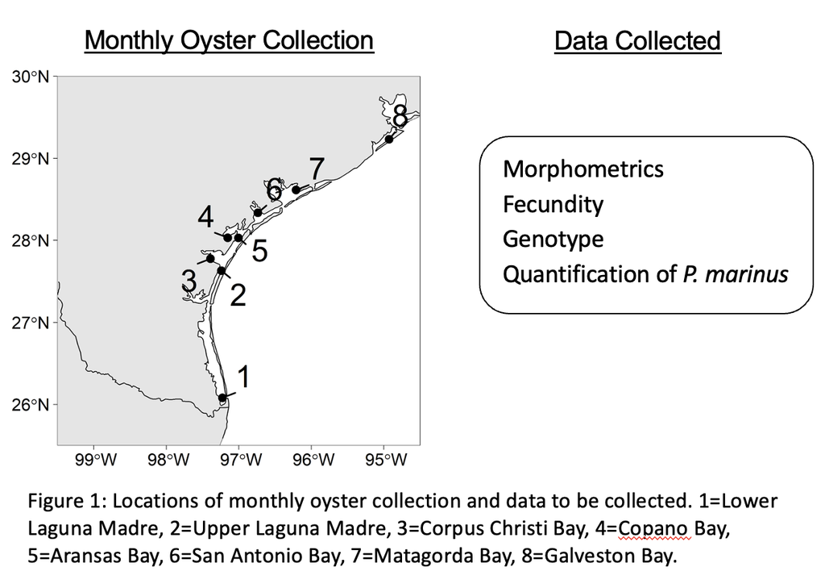

Fig 1

Sample locations were multiple sites in the Lower Laguna Madre, Upper Laguna Madre, Corpus Christi Bay, Copano Bay, Aransas Bay, San Antonio Bay, Matagorda Bay, Galveston Bay (Figure 1). Fifteen to twenty five oysters (2 inches or larger) were sampled from each site per month, summing to 145 to 225 oyster per bay per month.

Size and fecundity was measured for each adult oyster. Fecundity was estimated for each female oyster by dissecting the eggs, and counting subsamples in a known volume. Fecundity in females is reported per gram of oyster tissue.

Each oyster was swabbed for measuring disease burden and for population genetic analysis. Swabs will be used for quantification of the number of cells of *Perksinsus marinus* using real time quantitative PCR assays. Genetic analysis will involve assignment of oysters to one of serveral genetic subpopulations present in the Gulf, estimates of genetic diversity, and estimates of genetic relatedness.

# Results

We have packaged data in the project into an interactive web application using the Shiny package in R. We are working on hosting this application on a website so anyone with the URL can explore the data.

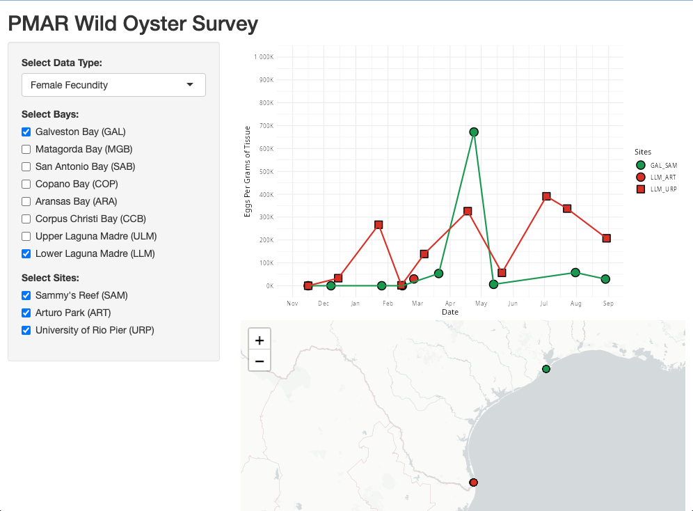

Fig 2

# Next Steps

1. Genetic analysis
- We are in the process of genotyping all oysters collected in April (n = 188) for the first look at the genetics of oysters at all our sampling sites. We expect to have that genetic analysis completed in October.
2. Disease burden
- We have started developing a qPCR assay for Perkinsus marinus at TAMUCC that will allow us to measure the number of P. marinus cells in all sampled oysters.
3. Multivariate analysis
- The data from this project is the subject of a masters thesis that aims to analyze the relationship among disease burden, genetics, and reproductive status.